# Lab 01 - Depth measures

Nonparametric statistics ay 2025/2026

2025-09-25

*Disclaimer 1: The present material is an adaptation of the original R script prepared by Dr. Matteo Fontana for the a.y. 2020/2021 Nonparametric statistics course, and later Prof. Andrea Cappozzo (a.y 2022-2023) While I acknowledge Matteo and Andrea for the (great) work done I hereby assume responsibility for any error that may be present in this document.*

*Disclaimer 2: I will start from the assumption that you are all intermediate R users, if this is not the case please let me know, and we shall find a solution together.*

## Loading necessary libraries

```r
library(MASS)
library(rgl)
library(DepthProc)
library(hexbin)
library(aplpack)
library(robustbase)
```

## Computing depths with R: some general ideas

Let us start by simulating $500$ bivariate datapoints whose distribution is marginally exponential

```r
set.seed(2781991) # reproducibility
n=500
df_bivariate_exp = cbind(rexp(n), rexp(n))
head(df_bivariate_exp)
```

```
##           [,1]       [,2]
## [1,] 0.3004277 0.35894610
## [2,] 2.4430839 0.22392999
## [3,] 1.8444128 0.15064919
## [4,] 0.2383688 1.12290176
## [5,] 1.9613656 0.07966151
## [6,] 5.2480885 0.01762207
```

and visualize their scatterplot

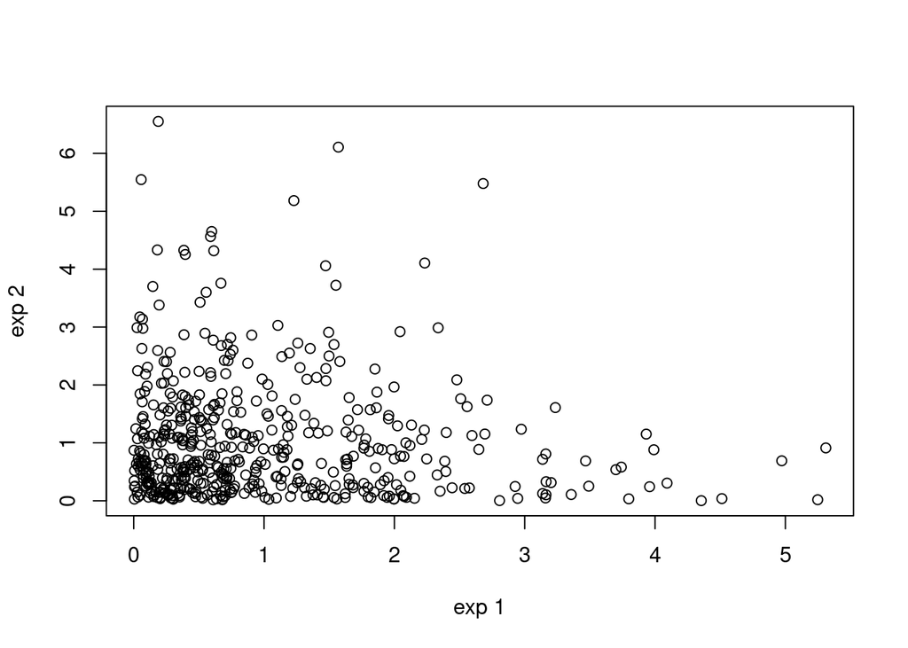

```r
plot(df_bivariate_exp[,1],df_bivariate_exp[,2], xlab="exp 1", ylab="exp 2")
```

We can further employ a hexagonal binning plot to visualize the data density

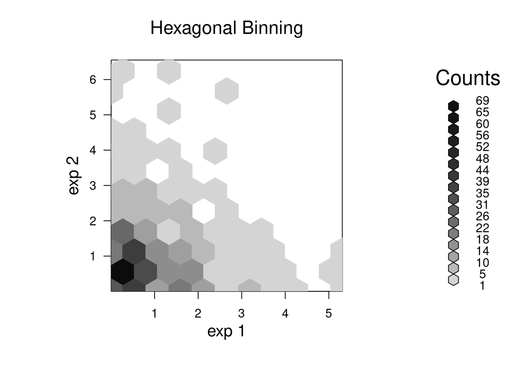

```r
bin=hexbin(df_bivariate_exp[,1],df_bivariate_exp[,2], xbins=10, xlab="exp 1", ylab="exp 2")
plot(bin, main="Hexagonal Binning")
```

### Depth measures (multivariate)

Now on depths: there are many possible packages hosted on CRAN to work with depths in a multivariate setting. We will hereafter use `DepthProc`, which is a good general purpose package and in addition it has good plotting capabilities. Even though not all depth measures introduced in class are directly available (simplicial, Oja, convex hull peeling depth), it includes the two depth measures we will be using throughout this section, namely **Tukey** and **Mahalanobis** depths. Let us look at the help file for the `depth` function.

Calculating depth for a given dataset is immediately accomplished by typing

```r
set.seed(20)
tukey_depth=depth(u=df_bivariate_exp,method='Tukey')
```

It may be useful (spoiler alert, it will become apparent why when we study onparametric forecasting) to calculate the depth of a point relative to a sample. You can do it by:

```r
depth(u = c(0.5, 0.5), X = df_bivariate_exp, method = 'Tukey')
```

```
## Depth method:  Tukey
## [1] 0.254
```

Compute the median (deepest point) with `depthMedian` function

```r
depthMedian(df_bivariate_exp,depth_params = list(method='Tukey'))
```

```
## [1] 0.8364350 0.9297927
```

Or, having already computed the Tukey depth for the entire sample:

```r
df_bivariate_exp[which.max(tukey_depth),]
```

```
## [1] 0.8364350 0.9297927
```

If you have the *luck* of dealing with a bivariate dataset, you can easily visualize the depth surface in a very convenient way. `DepthProc` offers you two possible methods:

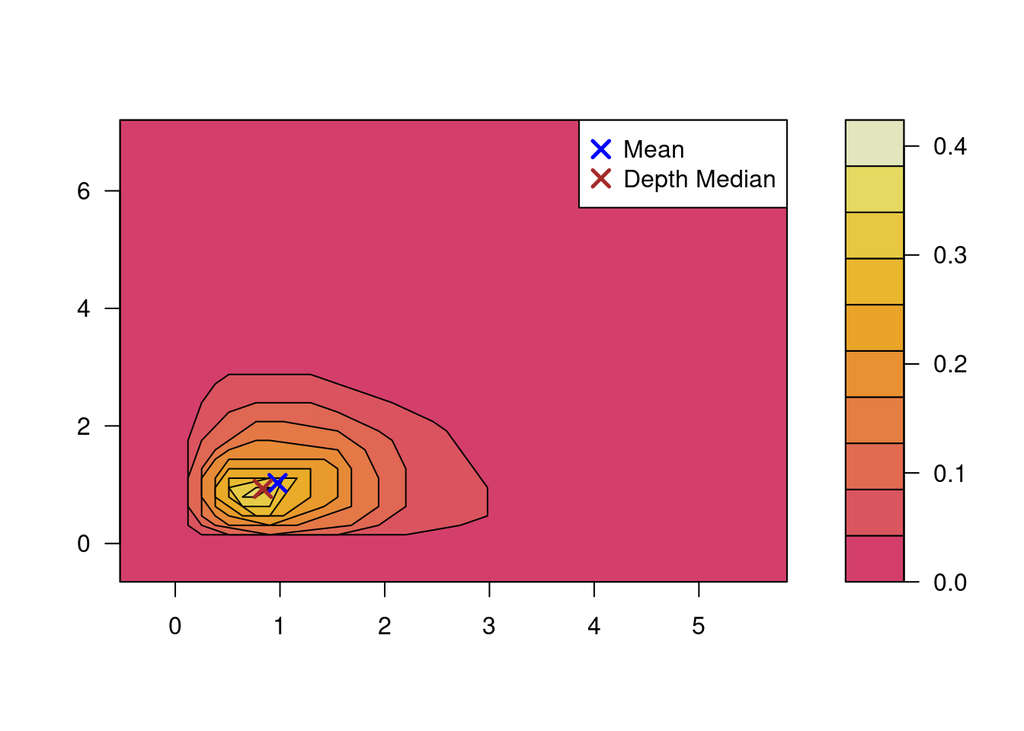

```r
DepthProc::depthContour(df_bivariate_exp,depth_params = list(method='Tukey'))
```

or

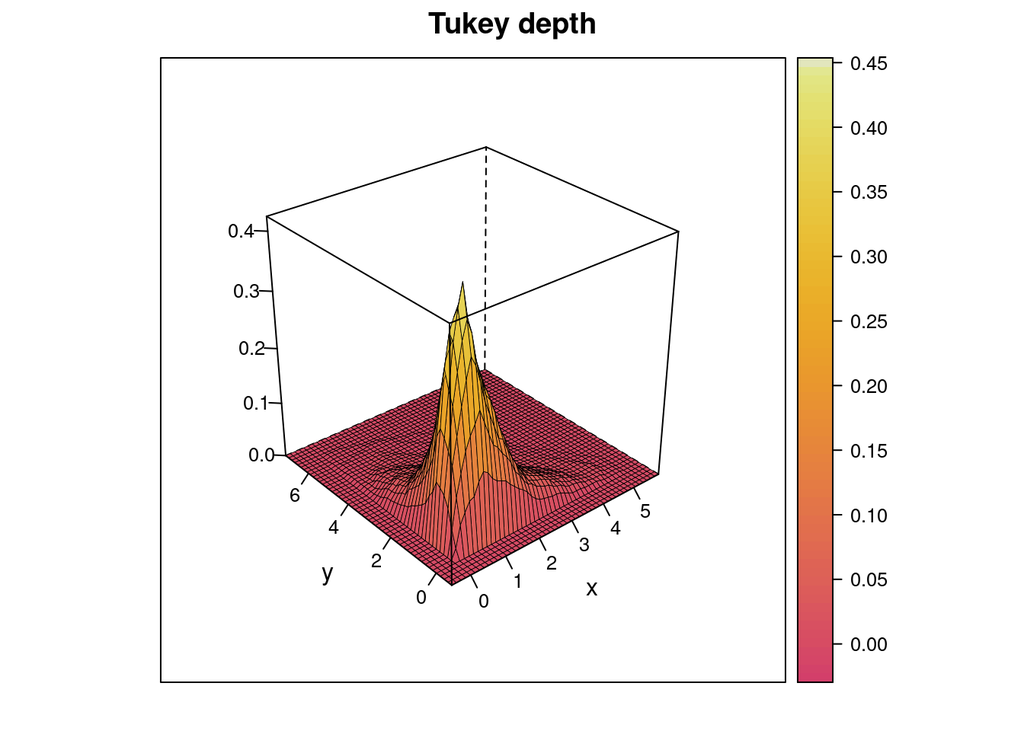

```r
depthPersp(df_bivariate_exp,depth_params = list(method='Tukey'))
```

For additional special effects:

```r
depthPersp(df_bivariate_exp,depth_params = list(method='Tukey'),plot_method = 'rgl')
```

[interactive chart not shown]